# PractWork3

## Практична робота №3. Алгоритми сортування та їх складність. Порівняння алгоритмів сортування

## Виконав: Буханцев Максим

**1. Вивчити самостійно і записати (будь-яким способом) алгоритм бульбашкового сортування. Оцінити асимптотику алгоритму сортування методом бульбашки в найгіршому і в найкращому випадку. Порівняти за цими показниками бульбашковий алгоритм з алгоритмом сортування вставлянням. Чому на практиці бульбашковий алгоритм виявляється менш ефективним у порівнянні з сортуванням методом зливанням?**

```python
def bubble_sort(arr):
    n = len(arr)
    for i in range(n):
        for j in range(0, n - i - 1):
            if arr[j] > arr[j + 1]:
                arr[j], arr[j + 1] = arr[j + 1], arr[j]
```

Різниця в їх асимптотичній складності призводить до різних найгірших сценаріїв: O(n^2) для бульбашки та O(nlog n) для злиття. Алгоритм сортування бульбашкою найкраще підходить для невеликих наборів даних, але зі збільшенням розміру набору даних він стає менш ефективним через тривалий час обробки. На відміну від нього, алгоритм сортування злиттям є більш ефективним, оскільки розбиває задачу на менші підзадачі, а потім збирає їх разом.

**2 . Оцінити асимптотичну складність алгоритму сортування зливанням, скориставшись основною теоремою рекурсії.**

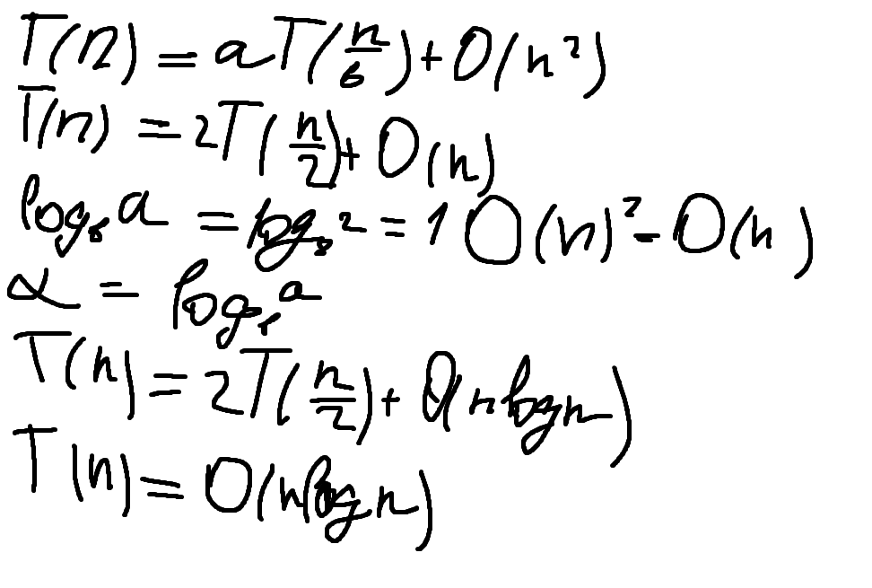

**3. Вивчити і записати (будь-яким способом) самостійно алгоритм швидкого сортування. Оцінити асимптотичну складність алгоритму швидкого сортування, скориставшись основною теоремою рекурсії.**

```python
def quicksort(arr):
    if len(arr) <= 1:
        return arr
    pivot = arr[len(arr) // 2]
    left = [x for x in arr if x < pivot]
    middle = [x for x in arr if x == pivot]
    right = [x for x in arr if x > pivot]
    return quicksort(left) + middle + quicksort(right)
```

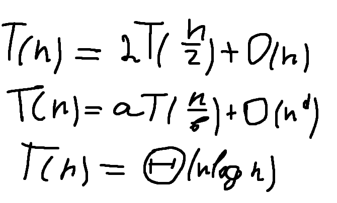

Асимптотична складність у середньому і найкращому випадку: O(nlogn) У найгіршому випадку: O(n^2)